# Decision Tree using caret in R.

### Gabriel Miranda

[figure not shown]

# Context:

#### Context:

The original dataset contains 1000 entries with 20 categorial/symbolic attributes prepared by Prof. Hofmann. In this dataset, each entry represents a person who takes a credit by a bank. Each person is classified as good or bad credit risks according to the set of attributes. The link to the original dataset can be found below.

# Content:

#### Content:

It is almost impossible to understand the original dataset due to its complicated system of categories and symbols. Thus, I wrote a small Python script to convert it into a readable CSV file. Several columns are simply ignored, because in my opinion either they are not important or their descriptions are obscure. The selected attributes are:

Age (numeric) Sex (text: male, female) Job (numeric: 0 - unskilled and non-resident, 1 - unskilled and resident, 2 - skilled, 3 - highly skilled) Housing (text: own, rent, or free) Saving accounts (text - little, moderate, quite rich, rich) Checking account (numeric, in DM - Deutsch Mark) Credit amount (numeric, in DM) Duration (numeric, in month) Purpose (text: car, furniture/equipment, radio/TV, domestic appliances, repairs, education, business, vacation/others)

#### [Click here to download the dataset](https://www.kaggle.com/kabure/german-credit-data-with-risk)

# First steps

```r
# Packages used

require(mlr)
require(ggplot2)
require(dplyr)
require(ggcorrplot)
require(caret)
require(rpart.plot)
```

```r
# Reading the database

df = read.csv('german_credit_risk_target.csv')
head(df, n = 10)
```

```
##    X Age    Sex Job Housing Saving.accounts Checking.account Credit.amount
## 1  0  67   male   2     own            <NA>           little          1169
## 2  1  22 female   2     own          little         moderate          5951
## 3  2  49   male   1     own          little             <NA>          2096
## 4  3  45   male   2    free          little           little          7882
## 5  4  53   male   2    free          little           little          4870
## 6  5  35   male   1    free            <NA>             <NA>          9055
## 7  6  53   male   2     own      quite rich             <NA>          2835
## 8  7  35   male   3    rent          little         moderate          6948
## 9  8  61   male   1     own            rich             <NA>          3059
## 10 9  28   male   3     own          little         moderate          5234
##    Duration             Purpose Risk
## 1         6            radio/TV good
## 2        48            radio/TV  bad
## 3        12           education good
## 4        42 furniture/equipment good
## 5        24                 car  bad
## 6        36           education good
## 7        24 furniture/equipment good
## 8        36                 car good
## 9        12            radio/TV good
## 10       30                 car  bad
```

Getting some information about the variables

```r
str(df)
```

```
## 'data.frame':    1000 obs. of  11 variables:
##  $ X               : int  0 1 2 3 4 5 6 7 8 9 ...
##  $ Age             : int  67 22 49 45 53 35 53 35 61 28 ...
##  $ Sex             : Factor w/ 2 levels "female","male": 2 1 2 2 2 2 2 2 2 2 ...
##  $ Job             : int  2 2 1 2 2 1 2 3 1 3 ...
##  $ Housing         : Factor w/ 3 levels "free","own","rent": 2 2 2 1 1 1 2 3 2 2 ...
##  $ Saving.accounts : Factor w/ 4 levels "little","moderate",..: NA 1 1 1 1 NA 3 1 4 1 ...
##  $ Checking.account: Factor w/ 3 levels "little","moderate",..: 1 2 NA 1 1 NA NA 2 NA 2 ...
##  $ Credit.amount   : int  1169 5951 2096 7882 4870 9055 2835 6948 3059 5234 ...
##  $ Duration        : int  6 48 12 42 24 36 24 36 12 30 ...
##  $ Purpose         : Factor w/ 8 levels "business","car",..: 6 6 4 5 2 4 5 2 6 2 ...
##  $ Risk            : Factor w/ 2 levels "bad","good": 2 1 2 2 1 2 2 2 2 1 ...
```

Look! The variable ‘Job’ is an int, but should be Factor. So we’re gonna turn it into Factor using the description offered by who posted the dataset on Kaggle.

```r
df$Job = factor(df$Job, levels = c(0, 1, 2, 3), labels = c('unskilled and non-resident',
                                                           'unskilled and resident', 'skilled',
                                                           'highly skilled'))

str(df)
```

```
## 'data.frame':    1000 obs. of  11 variables:
##  $ X               : int  0 1 2 3 4 5 6 7 8 9 ...
##  $ Age             : int  67 22 49 45 53 35 53 35 61 28 ...
##  $ Sex             : Factor w/ 2 levels "female","male": 2 1 2 2 2 2 2 2 2 2 ...
##  $ Job             : Factor w/ 4 levels "unskilled and non-resident",..: 3 3 2 3 3 2 3 4 2 4 ...
##  $ Housing         : Factor w/ 3 levels "free","own","rent": 2 2 2 1 1 1 2 3 2 2 ...
##  $ Saving.accounts : Factor w/ 4 levels "little","moderate",..: NA 1 1 1 1 NA 3 1 4 1 ...
##  $ Checking.account: Factor w/ 3 levels "little","moderate",..: 1 2 NA 1 1 NA NA 2 NA 2 ...
##  $ Credit.amount   : int  1169 5951 2096 7882 4870 9055 2835 6948 3059 5234 ...
##  $ Duration        : int  6 48 12 42 24 36 24 36 12 30 ...
##  $ Purpose         : Factor w/ 8 levels "business","car",..: 6 6 4 5 2 4 5 2 6 2 ...
##  $ Risk            : Factor w/ 2 levels "bad","good": 2 1 2 2 1 2 2 2 2 1 ...
```

Besides, we can see that ‘Saving.accounts’ and ‘Checking.account’ have some NA’s, but we don’t know if those are the only ones. Let’s check!

Verifying if there is any other variable with NA’s:

```r
apply(df, 2, function(x) any(is.na(x)))
```

```
##                X              Age              Sex              Job
##            FALSE            FALSE            FALSE            FALSE
##          Housing  Saving.accounts Checking.account    Credit.amount
##            FALSE             TRUE             TRUE            FALSE
##         Duration          Purpose             Risk
##            FALSE            FALSE            FALSE
```

See that the ‘Saving.accounts’ and ‘Checking.account’ columns are the only ones with NA’s, so we’re going to use a method to impute values on thoses NA’s values.

```r
set.seed(100)
imputer = mlr::impute(df, target = "Risk",
                     cols = list(Saving.accounts = imputeLearner("classif.rpart"),
                                 Checking.account = imputeLearner("classif.rpart")))

df = imputer$data
head(df, n = 10)
```

```
##    X Age    Sex                    Job Housing Saving.accounts Checking.account
## 1  0  67   male                skilled     own          little           little
## 2  1  22 female                skilled     own          little         moderate
## 3  2  49   male unskilled and resident     own          little           little
## 4  3  45   male                skilled    free          little           little
## 5  4  53   male                skilled    free          little           little
## 6  5  35   male unskilled and resident    free          little           little
## 7  6  53   male                skilled     own      quite rich           little
## 8  7  35   male         highly skilled    rent          little         moderate
## 9  8  61   male unskilled and resident     own            rich         moderate
## 10 9  28   male         highly skilled     own          little         moderate
##    Credit.amount Duration             Purpose Risk
## 1           1169        6            radio/TV good
## 2           5951       48            radio/TV  bad
## 3           2096       12           education good
## 4           7882       42 furniture/equipment good
## 5           4870       24                 car  bad
## 6           9055       36           education good
## 7           2835       24 furniture/equipment good
## 8           6948       36                 car good
## 9           3059       12            radio/TV good
## 10          5234       30                 car  bad
```

```r
str(df)
```

```
## 'data.frame':    1000 obs. of  11 variables:
##  $ X               : int  0 1 2 3 4 5 6 7 8 9 ...
##  $ Age             : int  67 22 49 45 53 35 53 35 61 28 ...
##  $ Sex             : Factor w/ 2 levels "female","male": 2 1 2 2 2 2 2 2 2 2 ...
##  $ Job             : Factor w/ 4 levels "unskilled and non-resident",..: 3 3 2 3 3 2 3 4 2 4 ...
##  $ Housing         : Factor w/ 3 levels "free","own","rent": 2 2 2 1 1 1 2 3 2 2 ...
##  $ Saving.accounts : Factor w/ 4 levels "little","moderate",..: 1 1 1 1 1 1 3 1 4 1 ...
##  $ Checking.account: Factor w/ 3 levels "little","moderate",..: 1 2 1 1 1 1 1 2 2 2 ...
##  $ Credit.amount   : int  1169 5951 2096 7882 4870 9055 2835 6948 3059 5234 ...
##  $ Duration        : int  6 48 12 42 24 36 24 36 12 30 ...
##  $ Purpose         : Factor w/ 8 levels "business","car",..: 6 6 4 5 2 4 5 2 6 2 ...
##  $ Risk            : Factor w/ 2 levels "bad","good": 2 1 2 2 1 2 2 2 2 1 ...
```

Now we’re gonna do some exploratory analysis to understand our dataset.

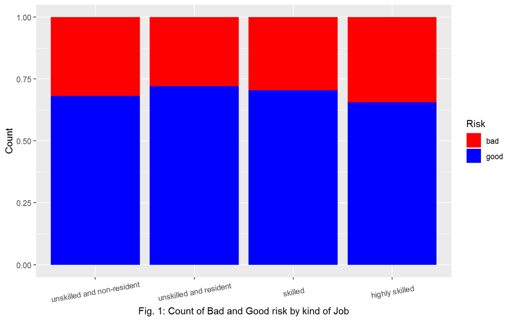

```r
ggplot(data = df, aes(x = Job, fill = Risk)) + geom_bar(position='fill') +
  labs(y = 'Count', x = 'Fig. 1: Count of Bad and Good risk by kind of Job') +
  theme(axis.text.x = element_text(angle=10, vjust=0.6)) +
  scale_fill_manual(values=c('red', 'blue'))
```

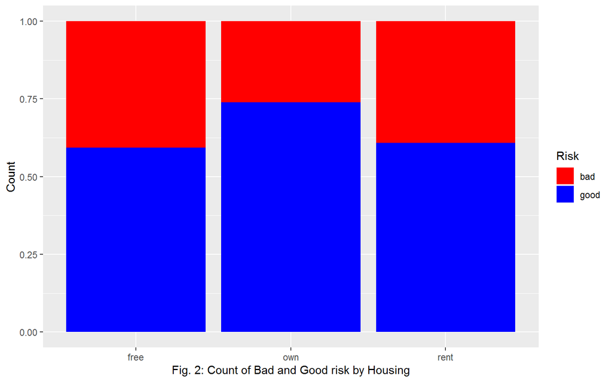

```r
ggplot(data = df, aes(x = Housing, fill = Risk)) + geom_bar(position='fill') +
  labs(y = 'Count', x = 'Fig. 2: Count of Bad and Good risk by Housing') +
  scale_fill_manual(values=c('red', 'blue'))
```

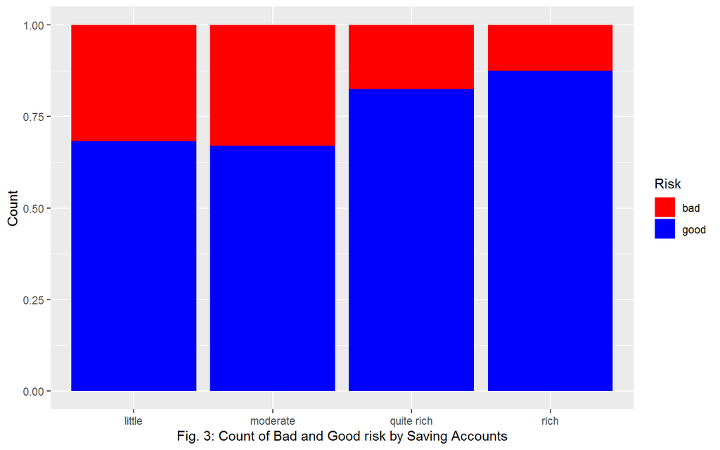

```r
ggplot(data = df, aes(x = Saving.accounts, fill = Risk)) + geom_bar(position='fill') +
  labs(y = 'Count', x = 'Fig. 3: Count of Bad and Good risk by Saving Accounts') +
  scale_fill_manual(values=c('red', 'blue'))
```

We can see that ‘little’ and ‘moderate’ are very similar, as ‘quite rich’ and ‘rich’. So we can make two categories by four to simplify our model.

```r
df$Saving.accounts =  as.factor(if_else(df$Saving.accounts == 'little' | df$Saving.accounts == 'moderate',
                             'little/moderate', 'quite rich/rich'))
```

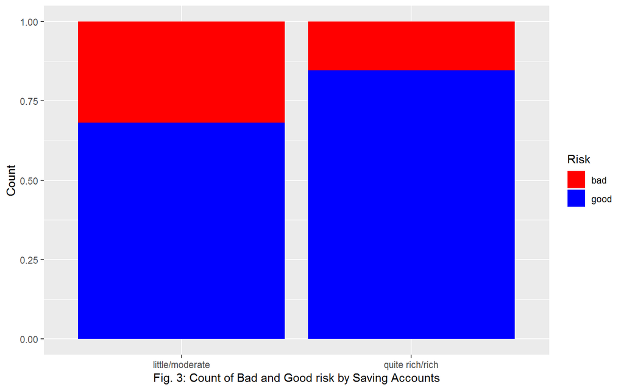

```r
ggplot(data = df, aes(x = Saving.accounts, fill = Risk)) + geom_bar(position='fill') +
  labs(y = 'Count', x = 'Fig. 3: Count of Bad and Good risk by Saving Accounts') +
  scale_fill_manual(values=c('red', 'blue'))
```

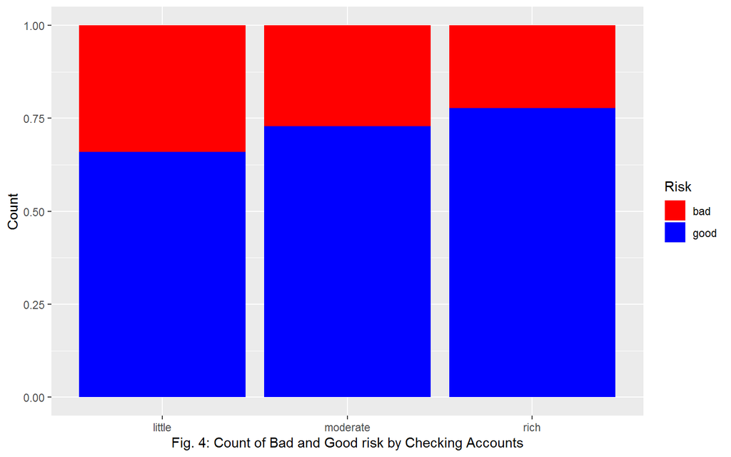

```r
ggplot(data = df, aes(x = Checking.account, fill = Risk)) + geom_bar(position='fill') +
  labs(y = 'Count', x = 'Fig. 4: Count of Bad and Good risk by Checking Accounts') +
  scale_fill_manual(values=c('red', 'blue'))
```

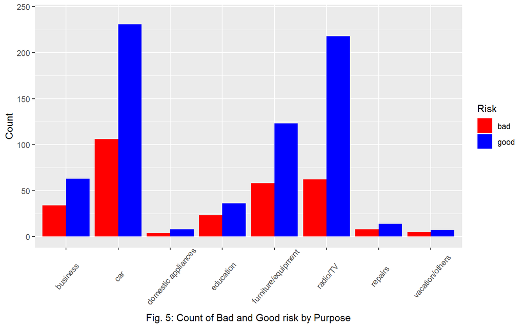

```r
ggplot(data = df, aes(x = Purpose, fill = Risk)) + geom_bar(position=position_dodge()) +
  labs(y = 'Count', x = 'Fig. 5: Count of Bad and Good risk by Purpose') +
  theme(axis.text.x = element_text(angle=50, vjust=0.6)) + ylim(0, 240) +
  scale_fill_manual(values=c('red', 'blue'))
```

```r
bad_risk = df %>% filter(Risk == 'bad')

good_risk = df %>% filter(Risk == 'good')
```

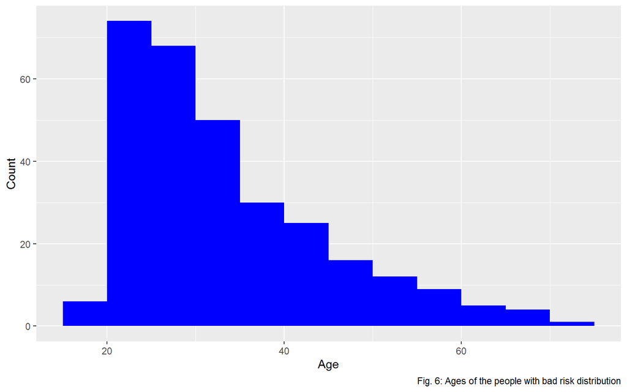

```r
ggplot(data = bad_risk, aes(x = Age)) + geom_histogram(fill = 'blue',
                                                       breaks = c(seq(15, 75, 5))) +
  labs(y = 'Count', x = 'Age', caption = 'Fig. 6: Ages of the people with bad risk distribution')
```

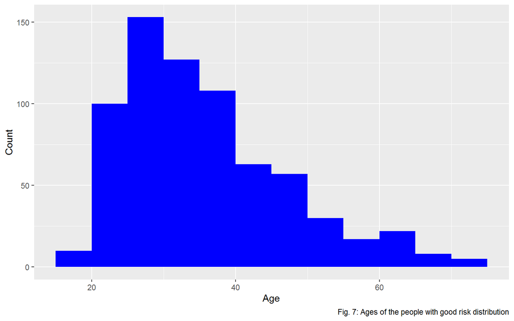

```r
ggplot(data = good_risk, aes(x = Age)) + geom_histogram(fill = 'blue',
                                                        breaks = c(seq(15, 75, 5))) +
  labs(y = 'Count', x = 'Age', caption = 'Fig. 7: Ages of the people with good risk distribution')
```